# Clustering workflow using binarized single-cell RNA-seq data

2022-11-01

This markdown is supplement to the paper: [The rise of sparser single-cell RNA-seq dataset; consequences and opportunities](https://doi.org/10.1101/2022.05.20.492823). In this markdown we perform a complete clustering workflow using **only** binarized single-cell RNA-seq data. This workflow contains the following:

- Finding a representative set of genes.
- Clustering of cells.
- Generating a UMAP plot.
- Identification of marker genes.
- Cell type annotation, using known marker genes.

# Packages

```r
require(ggplot2)
require(patchwork)
require(Matrix)
require(svd)
require(igraph)
require(dbscan)
require(locStra)
require(leiden)
require(knitr)
require(BRETIGEA)
require(reshape2)
```

# Load Functions

```r
for(i in list.files("./functions")){source(sprintf("./functions/%s",i))}
```

# Load Data

This single-cell brain dataset originates from [Grubman et al](https://doi.org/10.1038/s41593-019-0539-4). Cells without labels and doublets were removed, as well as cells originating from diseased individuals.

```r
data <- readRDS("./data/exampleData.rds")
counts <- data[[1]]
samplesheet <- data[[2]]
rm(data)
```

# Binarize Data

Binarizing is done by assigning a one to every non-zero value. Every zero remains a zero. The count matrix is removed, as it is not used for any downstream tasks.

```r
binary <- binarize(counts)
rm(counts)
```

# Find Representative Gene Set

```r
repGenes <- binaryRepGeneSet(binary)
```

# Clustering

For clustering, first the Jaccard cell-cell similarity matrix is calculated. Then, of this matrix, the eigen vectors are calculated. With these eigen vectors, using the euclidean distance, a shared nearest neighbor graph is constructed. This graph is fed to the Leiden clustering algorithm.

```r
clusters <- binaryClustering(binary = binary[repGenes,], reduction = "JEV", nc = 15)
```

## Make UMAP

For the UMAP, first the Jaccard cell-cell similarity matrix is calculated. Then, of this matrix, the eigen vectors are calculated. These eigen vectors are fed to the UMAP algorithm, again, using euclidean distance as metric.

```r
UMAP <- binaryUMAP(binary = binary[repGenes,], reduction = "JEV", nc = 15)
```

## Plot UMAP

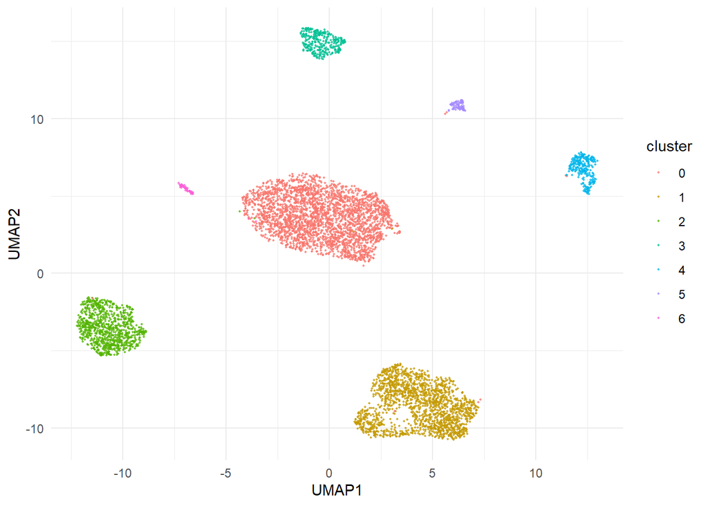

```r
plotData <- data.frame("UMAP1" = UMAP[,1],
                       "UMAP2" = UMAP[,2],
                       "cluster" = as.factor(clusters$cluster))
ggplot(plotData,aes(UMAP1,UMAP2, col = cluster)) + geom_point(size = 0.4, alpha = 0.7) + theme_minimal()
```

## Find Markers For Each Cluster

Markers are identified using Pearson’s correlation coefficient between binary matrix and the one-hot encoded cluster assignment matrix.

```r
markers <- findMarkers(binary,clusters = clusters$cluster)
```

## Top Markers Of Cluster 0

|  | gene | cluster | cor | p |
| --- | --- | --- | --- | --- |
| ST18 | ST18 | 0 | 0.7165694 | 0 |
| CTNNA3 | CTNNA3 | 0 | 0.6577817 | 0 |
| MBP | MBP | 0 | 0.6499621 | 0 |
| SLC24A2 | SLC24A2 | 0 | 0.6418860 | 0 |
| PLP1 | PLP1 | 0 | 0.6368628 | 0 |
| TMEM144 | TMEM144 | 0 | 0.6358883 | 0 |

## Binary Expression Of Cluster 0 Markers

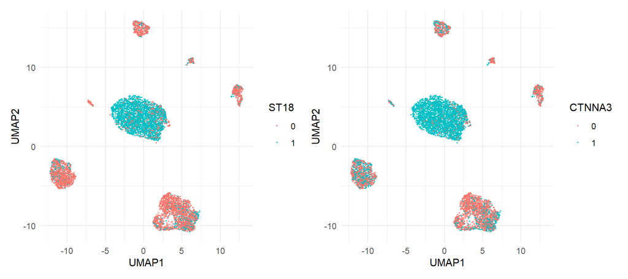

## Top Markers Of Cluster 1

|  | gene | cluster | cor | p |
| --- | --- | --- | --- | --- |
| RNF219-AS1 | RNF219-AS1 | 1 | 0.8212559 | 0 |
| ADGRV1 | ADGRV1 | 1 | 0.8006366 | 0 |
| RYR3 | RYR3 | 1 | 0.7440310 | 0 |
| TRPM3 | TRPM3 | 1 | 0.7163189 | 0 |
| PRKG1 | PRKG1 | 1 | 0.7043393 | 0 |
| MGAT4C | MGAT4C | 1 | 0.6852481 | 0 |

## Binary Expression Of Cluster 1 Markers

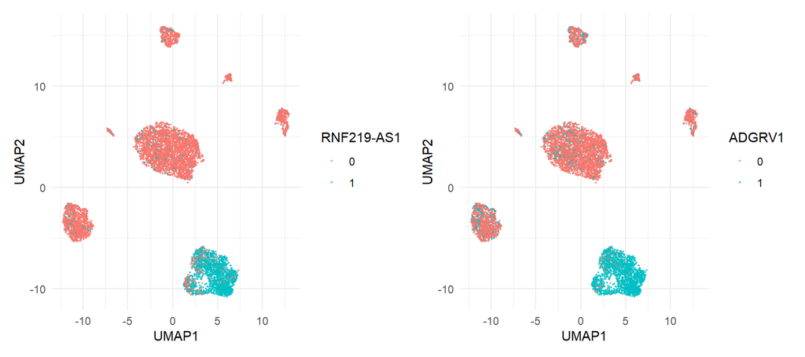

## Annotate clusters based on markers’ expression

```r
celltypes <- annotate_clusters(markers,BRETIGEA::markers_df_human_brain)
```

## Cell type assignments

| 1 | 4 | 0 | 5 | 2 | 3 | 6 |
| --- | --- | --- | --- | --- | --- | --- |
| ast | mic | oli | neu | opc | neu | end |

## UMAP with cell type labels and validation of cell type assignments

Binary-based annotations compared to original count-based annotations from [Grubman et al](https://doi.org/10.1038/s41593-019-0539-4).

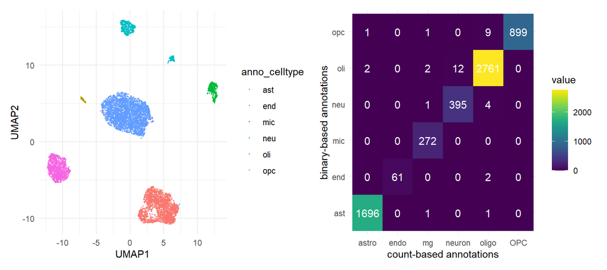